# Resampling Pennies Modern Dive Chapter 8

October 26, 2021 @ 12:16 PM

## Before We Begin…

These slides are not meant to be standalone information. You should take notes to flesh out the contents. I recommend that you create an R Markdown document where you can combine information and code from the slides and your own additional notes and explorations to make connections.

**Related Materials**

- Ch 5 of *Mathematical Statistics with Resampling and R, 2<sup>nd</sup> Ed.*
- [Ch 8](https://moderndive.com/8-confidence-intervals.html) of *Modern Dive*
- DataCamp [Sampling in R](https://learn.datacamp.com/courses/sampling-in-r)

## Packages

```r
library(tidyverse)
```

We need `tidyverse` for all our basic data manipulation. Recall that this includes `dplyr` and `ggplot`, among other packages in the `tidyverse` suite of tools.

```r
library(moderndive)
```

We need `moderndive` for some of the data and functions used in the pennies activity.

```r
library(infer)
```

We will use `infer` to compute confidence intervals in a `tidy`, algorithmic way (in #2).

## Bowl vs. Pennies

During the [Sampling Bowl Activity](https://stat-jet-asu.github.io/DCMDRDS/ModernDive/Slides/MDCH07SamplingBowlActivity.html#1) from Chapter 7 of Modern Dive, we sampled repeatedly from a population with a known proportion of red balls (\(p\)) versus white to understand how an *estimate* of the proportion of red balls (\(\hat{p}\)) taken from a sample can vary from sample to sample. We learned that:

- taking *more* samples helps us better characterize the shape, center, and spread of the sampling distribution, regardless of the sample size; and
- taking *larger* samples tends to decrease the variability of the statistic from sample to sample.

In most real-life scenarios, we only get to take *one* sample and do not know the population value. How can we study sampling variability when we only have one sample to work with?

## Sample: Pennies Circulating in 2019

Imagine all the pennies being used in the United States in 2019. What if we’re interested in the the average year in which all the pennies were minted? We would *have to* sample…

[figure not shown]

MD Figure 8.2: 50 US pennies labelled (pennies_sample).

## EDA on the `pennies_sample`

What is the shape, center, and spread (variability) of the sample?

- Create a histogram and QQ plot to assess shape
- Create a boxplot to detect the presence of outliers
- Compute the sample mean and standard deviation
- Also, tabulate the frequency (count) of different years

image source https://dribbble.com/shots/3613801-Tap-to-speak

## What is the Shape?

Visualize the shape of the distribution and check for outliers.

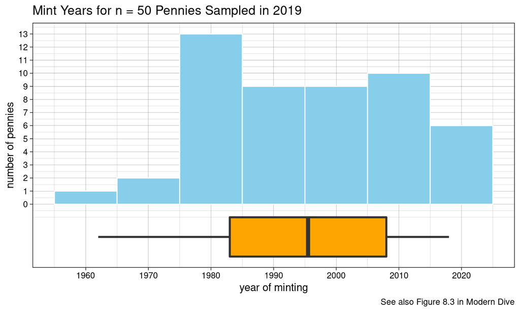

## Are the Data Approximately Normal?

Does the Normal QQ plot show a deviation from normality?

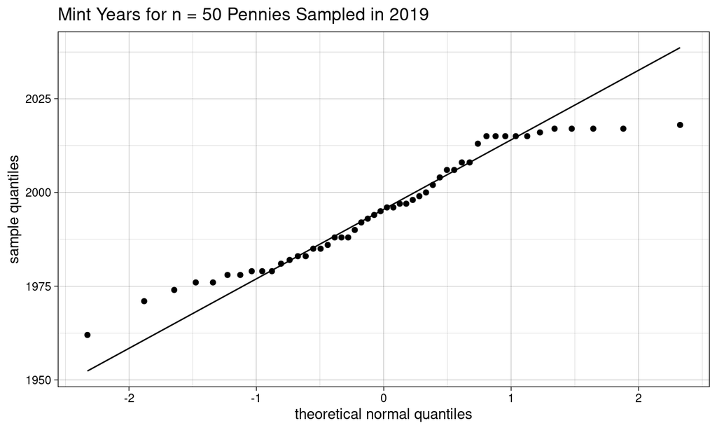

## Frequency of Years

```r
pennies_sample %>% count(year) %>% arrange(year)
```

```
# A tibble: 31 × 2
    year     n
   <dbl> <int>
 1  1962     1
 2  1971     1
 3  1974     1
 4  1976     2
 5  1978     2
 6  1979     3
 7  1981     1
 8  1982     1
 9  1983     2
10  1985     2
# … with 21 more rows
```

## Summaries of Years

If the pennies in `pennies_sample` are representative sample of all US pennies in circulation in 2019, then the sample mean \(\bar{x}\) is an unbiased estimate of the population mean \(\mu\).

| n | xbar | s |
| --- | --- | --- |
| 50 | 1995.44 | 15.18 |

The sample mean \(\bar{x}\) = 1995.44 (or about 1995, since we cannot have fractional years in context) is known as a *point estimate* of the population mean \(\mu\) because \(\bar{x}\) is a single value.

## Some Questions…

Did we sample with or without replacement here?

What is your best guess about the population size \(N\)?

Is it reasonable to assume the pennies are independent?

Do you think this sample is representative of pennies in 2019?

## Interval Estimates

While a point estimate is a single value, an *interval estimate* is a range of probable values for a population parameter.

To compute an interval estimate, we need to know the sampling distribution of the statistic we are using to estimate.

Traditional methods for \(\bar{x}\) are based on the normal distribution (thanks to the spectacular Central Limit Theorem).

*BUT* . . . assumptions must be met to use traditional methods.

Now we can use computational methods like *bootstrapping* to develop interval estimates, with fewer assumptions.

**bootstrap** (*verb*) : to get into or out of a situation using existing resources; as in, “to pull oneself up by one’s bootstraps.”

## The Bootstrap Idea

What is our “existing resource” here? It is the one sample we have.

From Chapter 5 of *Mathematical Statistics with Resampling and R, 2<sup>nd</sup> Ed.* (p. 104)

*“The original sample approximates the population from which it was drawn. So, resamples from this sample approximate what we would get if we took many samples from the population. The bootstrap distribution of a statistic, based on many resamples, approximates the sampling distribution of the statistic, based on many samples.”*

The BIG assumption: that our original sample is representative of the population.

## Bootstrap Resampling

Treat the sample as if it is the population.

Repeatedly resample from it *with replacement*.

Compute the relevant statistic from each resample.

Analyze the *re-*sampling distribution: shape, mean, SE.

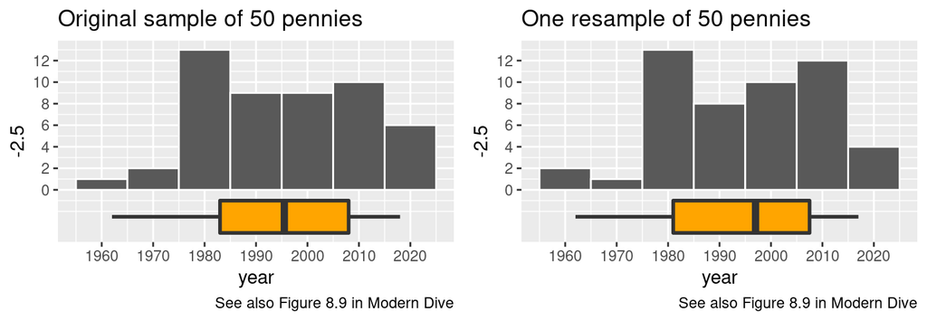

## Tactile Resampling 35 Times

As expected, there is sampling variability among the resamples.

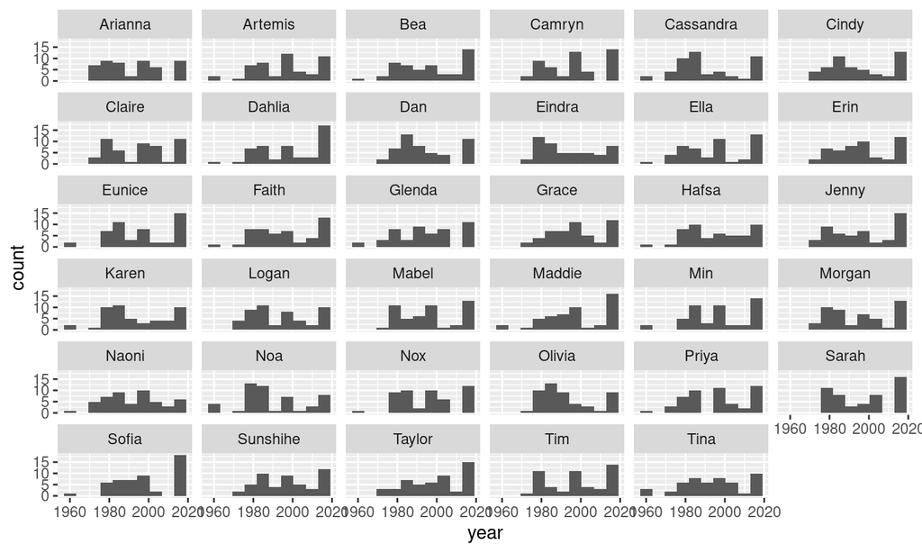

## Sample Mean of Each Resample

We compute the sample mean \(\bar{x}\) from each of the resamples and use them to approximate the sampling distribution of \(\bar{x}\).

```
# A tibble: 35 × 2
   name      mean_year
   <chr>         <dbl>
 1 Arianna       1992.
 2 Artemis       1996.
 3 Bea           1996.
 4 Camryn        1997.
 5 Cassandra     1991.
 6 Cindy         1995.
 7 Claire        1996.
 8 Dahlia        1998.
 9 Dan           1994.
10 Eindra        1994.
# … with 25 more rows
```

## Distribution of the Resample Means

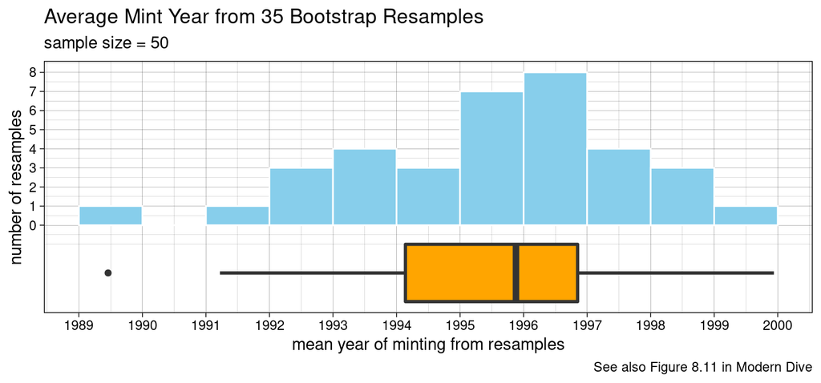

| resamples | xbar_resamplemeans | se_resamplemeans |
| --- | --- | --- |
| 35 | 1995.57 | 2.24 |

## Approximately Normal?

The authors of Modern Dive state, “Observe in Figure 8.11 that the distribution looks roughly normal…” Do you agree?

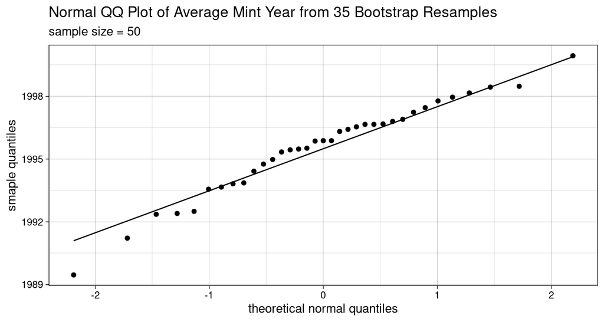

## Computer Simulation of Resampling

Our bootstrap resamples will be samples of size 50 drawn with replacement from the original sample (which had \(n\) = 50).

```r
my_virtual_resample <- pennies_sample %>%
  rep_sample_n(size = 50, replace = TRUE)   # drawn one sample
```

How can we virtually replicate the tactile resampling exercise, where 35 people each took one resample?

## Replicating the Tactile Resample

To replicate the tactile sample, we need 35 samples of size 50.

```r
virtual_resampled_means <- pennies_sample %>%
  rep_sample_n(size = 50, replace = TRUE, reps = 35) %>%
  group_by(replicate) %>%
  summarize(mean_year = mean(year))
```

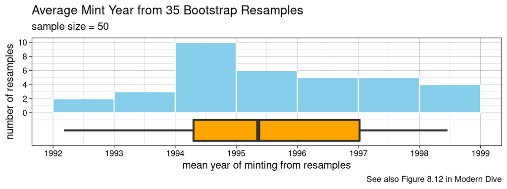

## More Samples, Better Estimate

Let’s take 1000 samples of size 50 to better “fill in the blanks”.

```r
virtual_resampled_means <- pennies_sample %>%
  rep_sample_n(size = 50, replace = TRUE, reps = 1000) %>%
  group_by(replicate) %>%
  summarize(mean_year = mean(year))
```

*Recall that…*

Changing the sample size (the size of individual samples) affects the properties of the sampling distribution itself.

Changing the number of resamples (reps) affects our ability to get stable estimates the properties of the sampling distribution (shape, center, spread).

## Distribution of the Resample Means

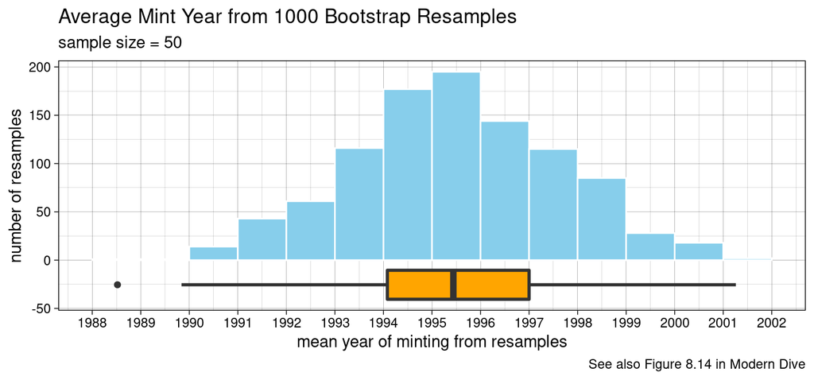

| resamples | xbar_resamplemeans | se_resamplemeans |
| --- | --- | --- |
| 1000 | 1995.51 | 2.12 |

## Approximately Normal?

Is the sampling distribution of \(\bar{x}\) approximately normal?

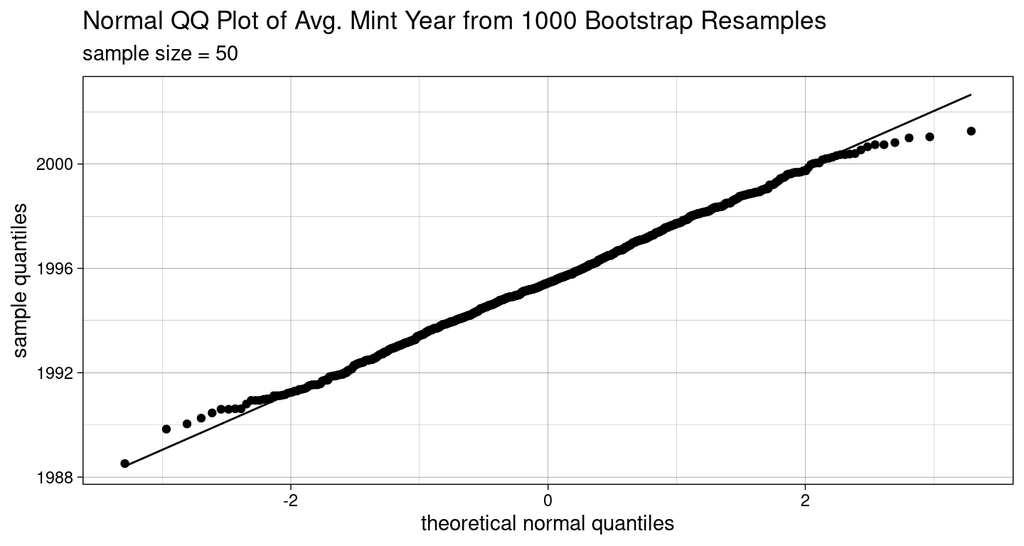

## Recap: Traditional Confidence Interval

If we feel the assumptions for a traditional confidence interval for \(\bar{x}\) are met, we could compute it from the original sample.

Assumptions:

- random (i.i.d.) sample from the population
- sample is less than 10% of the population
- the data appear normally distributed, or…
- \(n \ge 30\) with no significant outliers (CLT)

```r
t.test(pennies_sample$year)$conf.int
```

```
[1] 1991.127 1999.753
attr(,"conf.level")
[1] 0.95
```

## Bootstrap Percentile Interval

Using the same logic as a traditional confidence interval, a Y% bootstrap percentile interval is based on the middle Y% percent of the bootstrap sampling distribution.

But, instead of using the normal distribution (CLT), we use the bootstrap (simulated) sampling distribution.

```r
quantile(virtual_resampled_means$mean_year, c(0.025, 0.975))
```

```
    2.5%    97.5%
1991.300 1999.681
```

I am 95% confident that the true mean mint year \(\mu\) is between the two percentile values given above.

## Bootstrap SE Interval

If the bootstrap distribution appears approximately normal, we can use the bootstrap standard error in place of the theoretical standard error in the traditional confidence interval formula.

\[\bar{x}_{\text{original sample}} \pm z* SE_{\text{bootstrap distribution}}\]

```r
z <- 1.96

mean(pennies_sample$year) +
  c(-1, +1) * z * sd(virtual_resampled_means$mean_year)
```

```
[1] 1991.283 1999.597
```

I am 95% confident that the true mean mint year \(\mu\) is between the two values given above.

## Using the infer Package

The infer package contains pre-built functions that convert the steps we performed into a predictable workflow for estimation and (later) inference.

**Summarizing the Statistic in Original Sample**

```r
x_bar <- pennies_sample %>%    # which dataset?
  specify(response = year) %>% # which variable?
  calculate(stat = "mean")     # which statistic?
x_bar
```

```
Response: year (numeric)
# A tibble: 1 × 1
   stat
  <dbl>
1 1995.
```

**Bootstrap Resampling from the Original Sample**

We do not have to specify sample size, the `generate` function calculates that from the specified variable. The default type of generation is `bootstrap`, so we can leave that out if we wish.

```r
pennies_sample %>%
  specify(response = year) %>%
  generate(reps = 1000, type = "bootstrap") # what type of sampling?
```

```
Response: year (numeric)
# A tibble: 50,000 × 2
# Groups:   replicate [1,000]
   replicate  year
       <int> <dbl>
 1         1  1988
 2         1  1998
 3         1  1996
 4         1  1986
 5         1  2017
 6         1  2002
 7         1  2004
 8         1  2017
 9         1  2008
10         1  1998
# … with 49,990 more rows
```

**Calculate the Statistic from the Resamples**

```r
bootstrap_distribution <- pennies_sample %>%
  specify(response = year) %>%
  generate(reps = 1000) %>%
  calculate(stat = "mean") # distribution of what statistic?
bootstrap_distribution
```

```
Response: year (numeric)
# A tibble: 1,000 × 2
   replicate  stat
       <int> <dbl>
 1         1 1995.
 2         2 1997.
 3         3 1998.
 4         4 1998.
 5         5 1997.
 6         6 1995.
 7         7 1995.
 8         8 1996.
 9         9 1995.
10        10 1995.
# … with 990 more rows
```

**Visualize the Sampling Distribution**

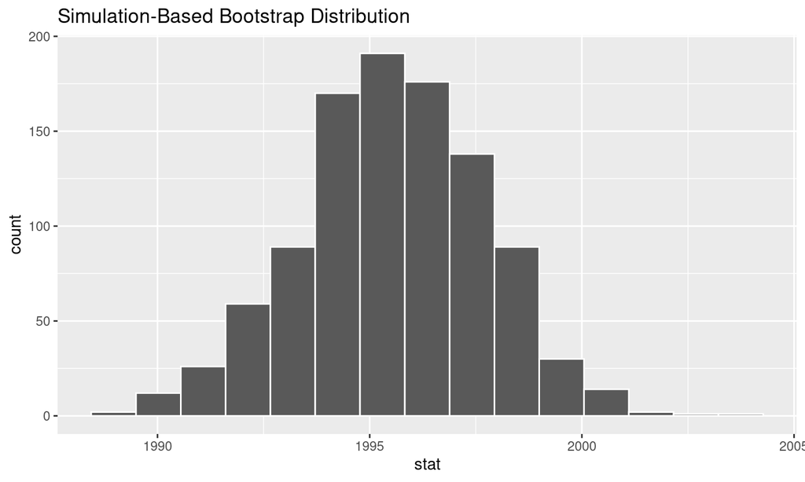

```r
visualize(bootstrap_distribution)
```

**Calculating the Intervals**

```r
percentile_ci <- bootstrap_distribution %>%
  get_confidence_interval(level = 0.95, type = "percentile")
percentile_ci
```

```
# A tibble: 1 × 2
  lower_ci upper_ci
     <dbl>    <dbl>
1    1991.    2000.
```

```r
standard_error_ci <- bootstrap_distribution %>%
  get_confidence_interval(type = "se", point_estimate = x_bar)
standard_error_ci
```

```
# A tibble: 1 × 2
  lower_ci upper_ci
     <dbl>    <dbl>
1    1991.    2000.
```

**Visualizing the Percentile Interval**

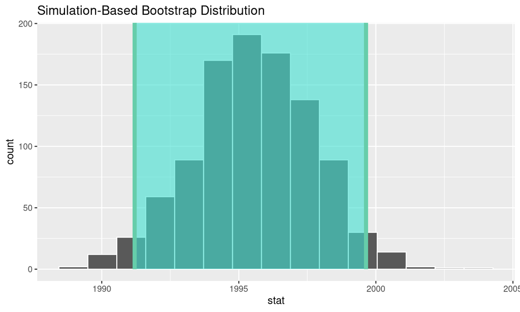

```r
visualize(bootstrap_distribution) +
  shade_confidence_interval(endpoints = percentile_ci)
```

**Visualizing the SE Interval**

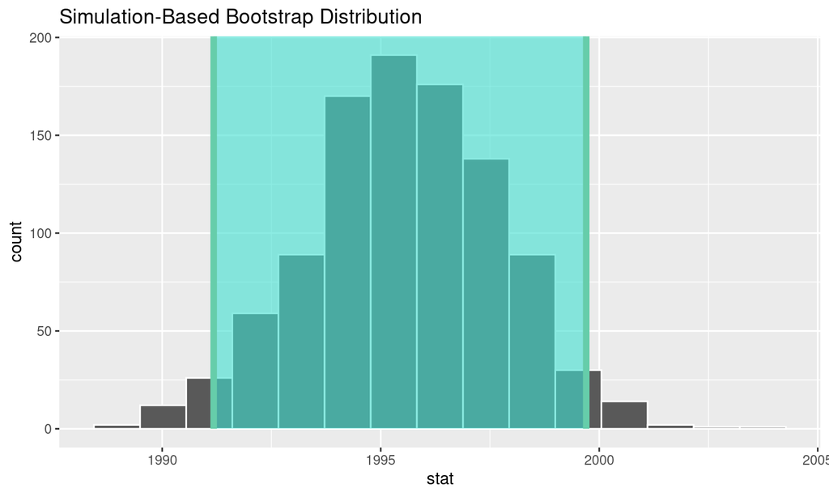

```r
visualize(bootstrap_distribution) +
  shade_confidence_interval(endpoints = standard_error_ci)
```

## Resampling with a `for` Loop

For very large numbers of reps, it is more time-efficient to use a `for` loop than to use `rep_sample_n`.

```r
reps  <- 10^5                           # number of re-samples
years <- pennies_sample %>% pull(year)  # extract the variable
mean_year <- numeric(reps)         # initialize storage vector

for (i in 1:reps) {
  mean_year[i] <- mean(sample(years, size = 50, replace = TRUE))
}

virtual_resampled_means <- tibble(replicate = 1:reps, mean_year)
```

The variable *i* serves as both a loop counter and vector location, which is why we initiate the `for` loop from 1 (there is no location zero in a mathematical vector).

## Distribution of the Resample Means

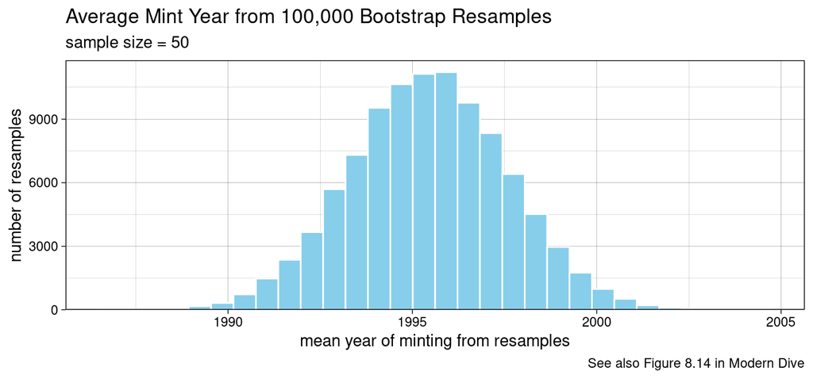

| resamples | xbar | se |
| --- | --- | --- |
| 1e+05 | 1995.44 | 2.13 |